# Analysis of Exxon Mobil Stock Price - Cindy

Analysis Include:

#### 1. Data Collection and Cleaning

#### 2. Data Storage

#### 3. Descriptive Analysis (Central Tendencies & Variability & Distribution of Exxon Stocl Price)

#### 4. Decomposition Model (Seasonality Trend)

#### 5. Correlation and regression Analysis (Petroleum price/natural gas price/S&P 500 indicator

# 1. Data Collection and Cleaning

```python
from pandas_datareader import data as pdr
import yfinance as yf
yf.pdr_override()
from datetime import datetime
```

### a ) Retriving Exxon stock price and SP500 price data 2019/01 - 2023/12

```python
start_date = datetime(2019,1,1)
end_date = datetime(2023,12,31)

# Get Exxon stock price and SP500 price data from yahoo
exxon = pdr.get_data_yahoo('XOM', start = start_date, end = end_date)
sp500 = pdr.get_data_yahoo('^GSPC', start = start_date, end = end_date)
```

```
[*********************100%%**********************]  1 of 1 completed
[*********************100%%**********************]  1 of 1 completed
```

### b ) Get daily and monthly price from 2019/01 to 2023/12 : use Adj Close price for following analysis.

```python
exxon_daily = exxon['Adj Close'].reset_index().set_index('Date')
sp500_daily = sp500['Adj Close'].reset_index().set_index('Date')
exxon_daily.head(3)
```

| Date | Adj Close |
| --- | --- |
| 2019-01-02 | 53.465630 |
| 2019-01-03 | 52.644714 |
| 2019-01-04 | 54.585712 |

```python
sp500_daily.head(3)
```

| Date | Adj Close |
| --- | --- |
| 2019-01-02 | 2510.030029 |
| 2019-01-03 | 2447.889893 |
| 2019-01-04 | 2531.939941 |

```python
import datetime as dt
exxon_monthly = exxon_daily.resample('M').mean().reset_index()
exxon_monthly['Date'] = exxon_monthly['Date'].dt.strftime('%Y-%m')
exxon_monthly = exxon_monthly.rename(columns = {'Adj Close':'Exxon'})
exxon_monthly.head(3)
```

|  | Date | Exxon |
| --- | --- | --- |
| 0 | 2019-01 | 54.941913 |
| 1 | 2019-02 | 59.382950 |
| 2 | 2019-03 | 62.364457 |

```python
sp500_monthly = sp500_daily.resample('M').mean().reset_index()
sp500_monthly['Date'] = sp500_monthly['Date'].dt.strftime('%Y-%m')
sp500_monthly = sp500_monthly.rename(columns = {'Adj Close':'SP500'})
sp500_monthly.head(3)
```

|  | Date | SP500 |
| --- | --- | --- |
| 0 | 2019-01 | 2607.389997 |
| 1 | 2019-02 | 2754.864206 |
| 2 | 2019-03 | 2803.983794 |

### c ) Scraping Petroleum price and natural gas price time series data from EIA.

```python
import requests
```

```python
## Get Other Energer price time series data from EIA
api_key = '1M2c5NLB9fhkzuJr2PNhgalBfjZWP5DUBdNJWPxx'
petro_url = 'https://api.eia.gov/v2/petroleum/pri/spt/data/?frequency=monthly&data[0]=value&start=2019-01&end=2023-12&sort[0][column]=period&sort[0][direction]=desc&offset=0&length=5000'
gas_url = 'https://api.eia.gov/v2/natural-gas/pri/rescom/data/?frequency=monthly&data[0]=value&start=2019-01&end=2023-12&sort[0][column]=period&sort[0][direction]=desc&offset=0&length=5000'

petro = requests.get(f'{petro_url}&api_key={api_key}')
gas_ = requests.get(f'{gas_url}&api_key={api_key}')


petroleum = petro.json()
gas = gas_.json()
```

### d ) Get monthly price from 2019/01 to 2023/12

Convert json file to DataFrame

```python
import pandas as pd
gas_data = gas['response']['data']
gas_data = pd.DataFrame(gas_data)
gas_data.head(5)
gas_data['value'] = pd.to_numeric(gas_data['value'])
```

```python
## check if there is any NULL value
gas_data.value.isna().sum()
```

```
10
```

```python
## check out NULL value
gas_data['isna'] = gas_data.value.isna()
check = gas_data[gas_data['isna'] == True]
check.head(2)
```

|  | period | duoarea | area-name | product | product-name | process | process-name | series | series-description | value | units | isna |
| --- | --- | --- | --- | --- | --- | --- | --- | --- | --- | --- | --- | --- |
| 48 | 2023-09 | SNJ | USA-NJ | EPG0 | Natural Gas | PCS | Price Delivered to Commercial Sectors | N3020NJ3 | New Jersey Price of Natural Gas Sold to Commer... | NaN | $/MCF | True |
| 49 | 2023-09 | SVA | USA-VA | EPG0 | Natural Gas | PCS | Price Delivered to Commercial Sectors | N3020VA3 | Virginia Price of Natural Gas Sold to Commerci... | NaN | $/MCF | True |

```python
## drop NULL value
gas_data.dropna(subset = ['value'], inplace = True)
gas_data.head(2)
```

|  | period | duoarea | area-name | product | product-name | process | process-name | series | series-description | value | units | isna |
| --- | --- | --- | --- | --- | --- | --- | --- | --- | --- | --- | --- | --- |
| 0 | 2023-11 | SDC | USA-DC | EPG0 | Natural Gas | PRS | Price Delivered to Residential Consumers | N3010DC3 | District of Columbia Price of Natural Gas Deli... | 16.43 | $/MCF | False |
| 1 | 2023-11 | SMI | USA-MI | EPG0 | Natural Gas | PRS | Price Delivered to Residential Consumers | N3010MI3 | Michigan Price of Natural Gas Delivered to Res... | 10.20 | $/MCF | False |

```python
gas_data.value.isna().sum()
```

```
0
```

```python
GAS = gas_data.groupby('period')['value'].mean().reset_index()
GAS = GAS.rename(columns = {'period':'Date','value':'Gas'})
GAS.head(3)
```

|  | Date | Gas |
| --- | --- | --- |
| 0 | 2019-01 | 9.9075 |
| 1 | 2019-02 | 9.8790 |
| 2 | 2019-03 | 9.8910 |

```python
petroleum_data = petroleum['response']['data']
petroleum_data = pd.DataFrame(petroleum_data)
petroleum_data['value'] = pd.to_numeric(petroleum_data['value'])
PETROLEUM = petroleum_data.groupby('period')['value'].mean().reset_index()
PETROLEUM = PETROLEUM.rename(columns = {'period':'Date','value':'Petroleum'})
PETROLEUM.head(3)
```

|  | Date | Petroleum |
| --- | --- | --- |
| 0 | 2019-01 | 11.352273 |
| 1 | 2019-02 | 12.189818 |
| 2 | 2019-03 | 12.764000 |

### e ) Combine monthly Data data

```python
data = exxon_monthly.merge(sp500_monthly, on = 'Date')
data2 = data.merge(GAS, on = 'Date')
Monthly_Avg_Price = data2.merge(PETROLEUM, on = 'Date')
```

### f ) Target Table

```python
Montly_Avg_Price.head(5)
```

|  | Date | Exxon | SP500 | Gas | Petroleum |
| --- | --- | --- | --- | --- | --- |
| 0 | 2019-01 | 54.941913 | 2607.389997 | 9.9075 | 11.352273 |
| 1 | 2019-02 | 59.382950 | 2754.864206 | 9.8790 | 12.189818 |
| 2 | 2019-03 | 62.364457 | 2803.983794 | 9.8910 | 12.764000 |
| 3 | 2019-04 | 63.287552 | 2903.799979 | 10.9775 | 13.870909 |
| 4 | 2019-05 | 59.008786 | 2854.705910 | 12.6380 | 13.549182 |

```python
exxon_daily.head(5)
```

| Date | Adj Close |
| --- | --- |
| 2019-01-02 | 53.465630 |
| 2019-01-03 | 52.644714 |
| 2019-01-04 | 54.585712 |
| 2019-01-07 | 54.869587 |
| 2019-01-08 | 55.268509 |

## 2. Data Storage

```python
exxon_daily.to_csv('/Users/cindy/Desktop/Koch/exxon_daily.csv')
Montly_Avg_Price.to_csv('/Users/cindy/Desktop/Koch/Montly_Avg_Price.csv')
```

## 3. Descriptive Analysis

### a ) Central Tendencies & Variability & Distribution of Exxon Stocl Price

```python
mean_price = exxon_daily['Adj Close'].mean()
median_price = exxon_daily['Adj Close'].median()

print(f"Mean of Adj Closing Price: {mean_price}")
print(f"Median of Adj Closing Price: {median_price}")
```

```
Mean of Adj Closing Price: 67.72684523032086
Median of Adj Closing Price: 58.27446365356445
```

```python
std_dev_price = exxon_daily['Adj Close'].std()
variance_price = exxon_daily['Adj Close'].var()

print(f"Standard Deviation of Adj Closing Prices: {std_dev_price}")
print(f"Variance of Closing Adj Prices: {variance_price}")
```

```
Standard Deviation of Adj Closing Prices: 25.815747994175116
Variance of Closing Adj Prices: 666.4528444987566
```

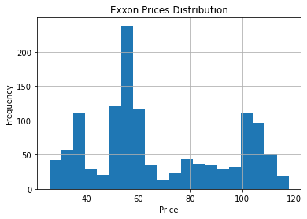

```python
import matplotlib.pyplot as plt
plt.figure(figsize = (6,4))
exxon_daily['Adj Close'].hist(bins=20)
plt.title('Exxon Prices Distribution')
plt.xlabel('Price')
plt.ylabel('Frequency')
plt.show()
```

### b ) Seasonality or Trends

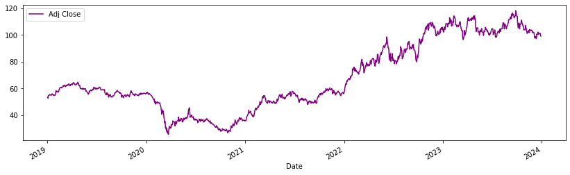

```python
exxon_daily.plot(figsize = (14,4),color = 'purple' )
```

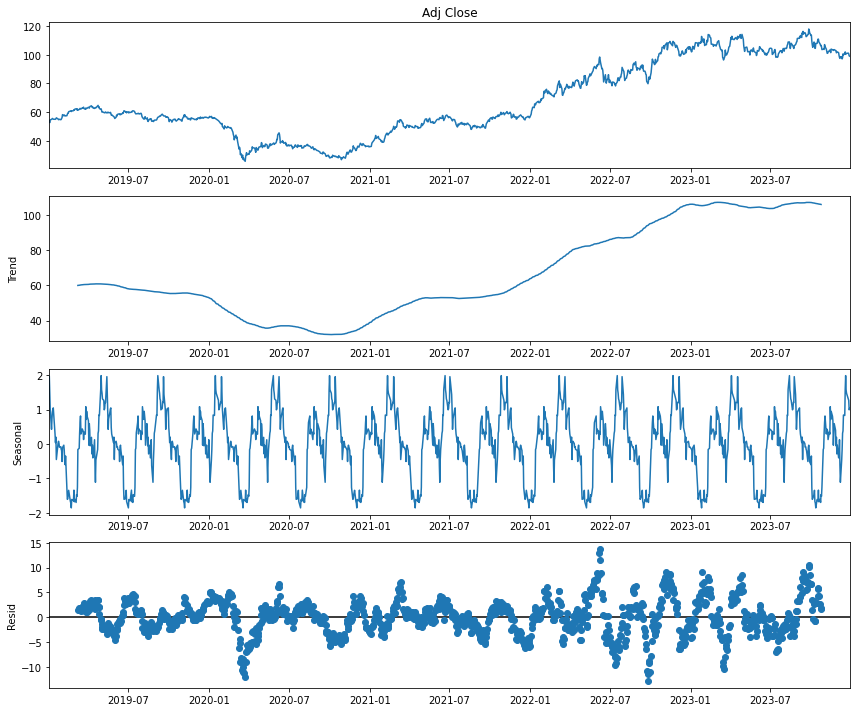

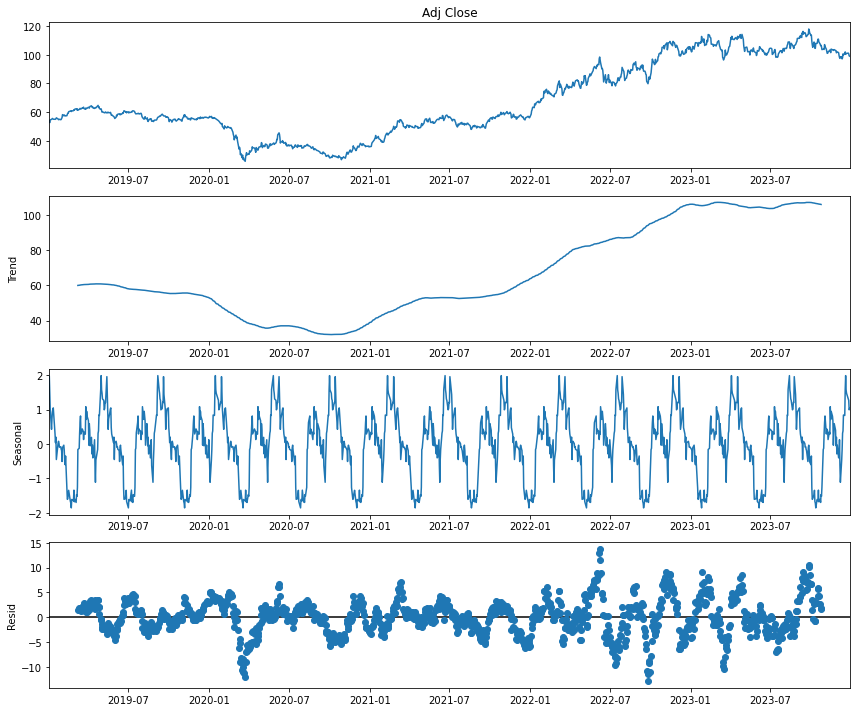

```python
from statsmodels.tsa.seasonal import seasonal_decompose
# Decompose the time series into three componients: trend, seasonality, residual
decomposition = seasonal_decompose(exxon_daily['Adj Close'], model='additive', period=90)  # Assuming a monthly seasonality
plt.figure(figsize = (20,4))
decomposition.plot()

#Specifies the type of decomposition.
#An additive model is used when the seasonal variations are roughly constant over time.
#The alternative is a 'multiplicative' model, which is used when seasonal variations increase or decrease over time.

#period=90: This defines the length of the seasonal cycle.
#where each month is approximated to have 90 trading days.


# Plot the decomposed components
```

## 4. Statistical Analysis

```python
Monthly_Avg_Price.head(5)
```

|  | Date | Exxon | SP500 | Gas | Petroleum |
| --- | --- | --- | --- | --- | --- |
| 0 | 2019-01 | 54.941913 | 2607.389997 | 9.9075 | 11.352273 |
| 1 | 2019-02 | 59.382950 | 2754.864206 | 9.8790 | 12.189818 |
| 2 | 2019-03 | 62.364457 | 2803.983794 | 9.8910 | 12.764000 |
| 3 | 2019-04 | 63.287552 | 2903.799979 | 10.9775 | 13.870909 |
| 4 | 2019-05 | 59.008786 | 2854.705910 | 12.6380 | 13.549182 |

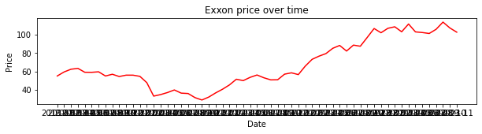

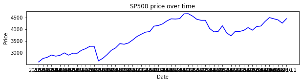

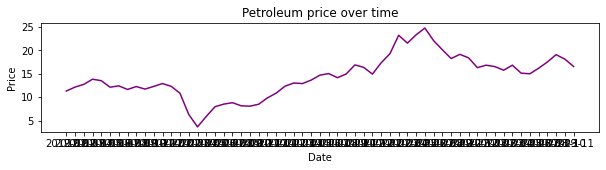

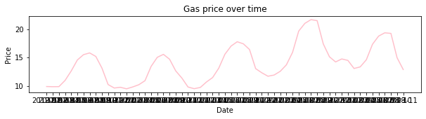

```python
plt.figure(figsize = (10,2))
plt.figure(1)
plt.plot(Monthly_Avg_Price['Date'], Monthly_Avg_Price['Exxon'], label = 'Exxon',color = 'red')
plt.xlabel('Date')
plt.ylabel('Price')
plt.title('Exxon price over time')

plt.grid

plt.figure(figsize = (10,2))
plt.figure(2)
plt.plot(Monthly_Avg_Price['Date'], Monthly_Avg_Price['SP500'], label = 'SP500',color = 'blue')
plt.xlabel('Date')
plt.ylabel('Price')
plt.title('SP500 price over time')

plt.grid


plt.figure(figsize = (10,2))
plt.figure(3)
plt.plot(Monthly_Avg_Price['Date'], Monthly_Avg_Price['Petroleum'], label = 'Petroleum',color = 'purple')
plt.xlabel('Date')
plt.ylabel('Price')
plt.title('Petroleum price over time')


plt.grid

plt.figure(figsize = (10,2))
plt.figure(4)
plt.plot(Monthly_Avg_Price['Date'], Monthly_Avg_Price['Gas'], label = 'Gas',color = 'pink')
plt.xlabel('Date')
plt.ylabel('Price')
plt.title('Gas price over time')
```

```python
correlations = Monthly_Avg_Price.drop('Date', axis=1).corr()
correlations
```

|  | Exxon | SP500 | Gas | Petroleum |
| --- | --- | --- | --- | --- |
| Exxon | 1.000000 | 0.496789 | 0.497148 | 0.744227 |
| SP500 | 0.496789 | 1.000000 | 0.434640 | 0.651425 |
| Gas | 0.497148 | 0.434640 | 1.000000 | 0.551218 |
| Petroleum | 0.744227 | 0.651425 | 0.551218 | 1.000000 |

## Correlation

```python
SP500_col = correlations['Exxon'].SP500
Petroleum_col = correlations['Exxon'].Petroleum
Gas_col = correlations['Exxon'].Gas
print(f'Correlations between Exxon price and SP500 is : {SP_col}')
print(f'Correlations between Exxon price and Petroleum price is : {Petroleum_col}')
print(f'Correlations between Exxon price and Gas price is : {Gas_col}')
```

```
Correlations between Exxon price and SP500 is : 0.4967886108355423
Correlations between Exxon price and Petroleum price is : 0.7442265599455116
Correlations between Exxon price and Gas price is : 0.4971481785610861
```

## Regression Model

```python
import statsmodels.api as sm
X = Monthly_Avg_Price[['SP500', 'Gas', 'Petroleum']]
y = Monthly_Avg_Price['Exxon']
X = sm.add_constant(X)
model = sm.OLS(y, X).fit()
print(model.summary())
```

```
                            OLS Regression Results
==============================================================================
Dep. Variable:                  Exxon   R-squared:                       0.565
Model:                            OLS   Adj. R-squared:                  0.541
Method:                 Least Squares   F-statistic:                     23.79
Date:                Sat, 02 Mar 2024   Prob (F-statistic):           5.31e-10
Time:                        01:32:25   Log-Likelihood:                -250.52
No. Observations:                  59   AIC:                             509.0
Df Residuals:                      55   BIC:                             517.3
Df Model:                           3
Covariance Type:            nonrobust
==============================================================================
                 coef    std err          t      P>|t|      [0.025      0.975]
------------------------------------------------------------------------------
const         -2.7169     15.066     -0.180      0.858     -32.911      27.477
SP500          0.0002      0.005      0.038      0.970      -0.010       0.010
Gas            0.9727      0.840      1.158      0.252      -0.711       2.656
Petroleum      3.8817      0.736      5.278      0.000       2.408       5.356
==============================================================================
Omnibus:                        6.039   Durbin-Watson:                   0.088
Prob(Omnibus):                  0.049   Jarque-Bera (JB):                5.365
Skew:                           0.656   Prob(JB):                       0.0684
Kurtosis:                       2.320   Cond. No.                     2.51e+04
==============================================================================

Notes:
[1] Standard Errors assume that the covariance matrix of the errors is correctly specified.
[2] The condition number is large, 2.51e+04. This might indicate that there are
strong multicollinearity or other numerical problems.
```

### R-squared: 0.565 Adj. R-squared: 0.541

indicates that approximately 56.5% of the variability in Exxon's prices can be explained by the model's inputs (SP500, Gas, Petroleum).

### p-value: 5.31e-10 ( very Low)

suggesting the model is statistically significant, and there is a relationship between the dependent and independent variables as a group.

### condition number: 2.51e+04

indicates potential Multicollinearity: two or more predictor variables in a regression model are highly correlated, making it difficult to isolate the effect of each predictor on the dependent variable.

### Regression Equation:

#### Exxon = −2.7169 + 0.0002 × (SP500) + 0.9727 × (Gas) + 3.8817 × (Petroleum)

## Adjusted Regression Model (Remove less related element)

```python
X2 = Monthly_Avg_Price['Petroleum']
y2 = Monthly_Avg_Price['Exxon']
X2 = sm.add_constant(X2)
model2 = sm.OLS(y2, X2).fit()
print(model2.summary())
```

```
                            OLS Regression Results
==============================================================================
Dep. Variable:                  Exxon   R-squared:                       0.554
Model:                            OLS   Adj. R-squared:                  0.546
Method:                 Least Squares   F-statistic:                     70.77
Date:                Sun, 03 Mar 2024   Prob (F-statistic):           1.43e-11
Time:                        23:29:33   Log-Likelihood:                -251.24
No. Observations:                  59   AIC:                             506.5
Df Residuals:                      57   BIC:                             510.6
Df Model:                           1
Covariance Type:            nonrobust
==============================================================================
                 coef    std err          t      P>|t|      [0.025      0.975]
------------------------------------------------------------------------------
const          5.6353      7.668      0.735      0.465      -9.720      20.991
Petroleum      4.2941      0.510      8.412      0.000       3.272       5.316
==============================================================================
Omnibus:                        6.533   Durbin-Watson:                   0.080
Prob(Omnibus):                  0.038   Jarque-Bera (JB):                5.679
Skew:                           0.671   Prob(JB):                       0.0585
Kurtosis:                       2.286   Cond. No.                         51.0
==============================================================================

Notes:
[1] Standard Errors assume that the covariance matrix of the errors is correctly specified.
```

### p-value: 1.43e-11( very Low)

suggesting the model is statistically significant, and there is a relationship between the dependent and independent variables as a group.

### Regression Equation:

#### Exxon = 5.6353 + 4.2941 × (Petroleum)